*Clasificaciones de QS World University*

[figure not shown]

- Obtención de datos públicos [Aquí](https://www.kaggle.com/divyansh22/qs-world-university-rankings)
- Proveniencia de los datos : **Calificaciones de universidades realizada por Quacquarelli Symmonds**

## I. Título del proyecto

**Comparación y análisis de la calidad internacional de universidades**

- Título corto: **Calidad universitaria**

## II. Introducción

### 2.1 Importancia

En primer lugar, esta investigación resulta de vital importancia para los estudiantes que están decidiendo dónde estudiar, puesto que suelen desear entrar a las mejores universidades. Para decidir cuáles son estas, suelen basarse en su renombre en lugar de considerar muchos otros factores tales como la locación, la reputación de los profesores, entre otros factores importantes que se verán en las variables de la presente investigación.

En segundo lugar, esta investigación podría llegar a servir a los trabajadores profesionales que presentan dudas acerca de qué casa universitaria es la adecuada para desarrollar tanto su pregrado como su posgrado. Este estudio funcionará a modo de referencia y respaldo para una mejor elección en ambos casos (estudiantes y profesionales), con una data internacional que nos permita a su vez distinguir qué país/ continente ofrece mejor calidad en educación universitaria, ya que hay muchas personas interesadas en estudiar en el extranjero.

Por último, este estudio será importante para las mismas universidades, puesto que pueden llegar a comprender los factores que le brindan la calidad a una universidad, de tal modo que puedan mejorar en esos aspectos a futuro.

[figure not shown]

### 2.2 Factibilidad

Es factible puesto que al contar con un Data Frame extenso y con variables abundantes y variadas, aseguramos la posibilidad de establecer diversas relaciones entre estas a fin de ofrecer información relevante para el público objetivo. Asimismo, la fuente de la base de datos es reconocida en este ámbito, por lo cual la investigación puede llegar a ser confiable y representativa.

[figure not shown]

### 2.3 Justificación

- Es *interesante* porque se podrá distinguir que país/ continente ofrece mejor educación universitaria de calidad, ya que hay muchas personas interesadas en estudiar en el extranjero.
- Es *factible* porque la información de la data está elaborada por una empresa de renombre y confianza mundial, la Quacquarelli Symmonds.
- Es *específico* porque nos centramos en una parte única del sector aprendizaje: el área de estudios superiores en universidades.
- Es *desconocido* porque existen muchos rankings de las mejores universidades, pero muy pocos o nada en cuanto a la educación universitaria por países y o continentes.

## III. Objetivos

### 3.1 Objetivo general:

Alcanzar una comprensión más profunda de los países y o continentes que ofrecen mejor educación superior y los factores que le brindan esta calidad.

### 3.2 Objetivo específicos:

- Analizar que variables se relacionan de mejor manera y más directamente a la calidad de enseñanza de una universidad.
- Analizar si las variables relacionadas a la investigación y a la apreciación internacional interactúan de manera directa con la antigüedad de las casas de estudio.

### 3.3. Preguntas de investigación

| Preguntas | Hipótesis | Variables Clave |
| --- | --- | --- |
| ¿Se relacionan de manera directa la cantidad de alumnos y el nivel de educación de la universidad? | Una universidad que llega a tener una gran cantidad de alumnado se puede calificar como popular y de trayectoria, entonces consideramos que el nivel de educación que posee es alto. | Clasificación de Tamaño / Puntaje de Reputación Académica |
| ¿Se encuentran aglomeradas en zonas específicas del globo las mejores universidades a nivel mundial? | Las mejores universidades del mundo se encuentran en lugares de alto desarrollo económico. Entre las principales podemos mencionar a países angloparlantes y países europeos. | Puntaje General / Continente |
| ¿Cuál es el nivel de diferencia entre universidades en la calificación general según la cantidad de años que llevan en funciones? | Las universidades con mayor tiempo en funcionamiento tienen una mayor experiencia y desarrollo académico en general | Puntaje General / Tiempo de Funcionamiento |
| ¿Producen más conocimiento las universidades con recorrido o universidades relativamente nuevas? ¿En cuánto difieren a este nivel? | Las universidades con una mayor antigüedad tendrán un mejor desempeño tanto cuantitativo como cualitativo al momento de producir conocimiento, esto en base a su experiencia y trayectoria. | Tiempo de Funcionamiento / Puntaje de Citas por Facultad |
| ¿Cuál es el país que produce más trabajos de investigación? ¿Qué continentes tienen una mejor calificación a nivel de información/ investigación generada? | Los países angloparlantes y europeos tienden a concentrar gran parte de la producción bibliográfica del mundo. | País / Puntaje de Citas por Facultad |
| ¿Dónde se encuentran las universidades con mayor apreciación de estudiantes internacionales? | Las universidades de los países angloparlantes y europeos son las más atractivas para estudiantes del extranjero. | País / Puntaje de la Proporción de Estudiantes Extranjeros |
| ¿De qué parte del mundo son las universidades con una mayor apreciación de la empresa o corporación en la que laboran sus estudiantes? | Las universidades angloparlantes y europeas son las más solicitadas y generan gran expectativa en empresas alrededor del mundo al momento de contratar trabajadores. | País / Puntaje de Reputación del Empleador |
| ¿Las universidades que se encuentran en el tope de la lista tienen un alto rango de estudiantes/ profesores extranjeros? | Las universidades con mayor cantidad de estudiantes y profesores extranjeros suelen ser las de mayor prestigio mundial. | Puntaje Total/ Puntaje de la Proporción de Estudiantes/Profesores Extranjeros |

## IV. Planificación

Para organizar la realización del proyecto del curso de Estadística y Probabilidades se elaboró un diagrama de Gantt, de tal manera que, gráficamente, se pueda apreciar las actividades planeadas y el tiempo que se dedicará a su elaboración. Se utilizó la aplicación Canva.com para la elaboración del diagrama:

[figure not shown]

## V. Marco Teórico

### 5.1. Población

La población del estudio se encuentra compuesta por más de 25 000 universidades o instituciones de educación superior alrededor del mundo.

### 5.2. Muestra:

Universidades del top 1024 del ranking “QS University 2020”

### 5.3. Unidad muestral:

Universidad del top 1024 del ranking “QS University 2020”

### 5.4. Muestreo:

Nuestra muestra es no aleatoria: esta es elegida de una de las más importantes y prestigiosas clasificaciones a lo largo del mundo: “QS World University Ranking 2020”. Esta clasificación está compuesta por más de mil universidades a lo largo del mundo. Además, esta base de datos se complementa con otra en la plataforma Kaggle, con la cual se amplió la cantidad de variables disponibles para el estudio.

El tipo de muestreo es discrecional: mediante este método, se aplica una técnica parecida a la del muestreo por conveniencia, pues el investigador recluta a los sujetos según sus criterios, pero en este caso los busca de acuerdo a lo que piensa que estos sujetos puedan aportar a la investigación.

La metodología seguida por la empresa encargada de la recopilación de datos (Quacquarelli Symonds) es la siguiente: se compone de 6 variables cuantitativas diferentes, cada una con el respectivo puesto o ranking que poseen las universidades por cada competencia. Estas variables y su porcentaje de aporte a la calificación final por universidad son las siguientes:

- Reputación académica (40 %)
- Reputación del empleador (10 %)
- Proporción de profesores/ estudiantes (20 %)
- Citas por facultad (20 %)
- Proporción de estudiantes internacionales/ profesores internacionales (5 % cada uno)

En base a estos seis parámetros y sus ponderaciones, como se mencionó antes, se obtiene la calificación final del centro de estudio (la cual indica la posición en la lista general).

Además, contamos con las variables adicionales que nos ayudan a establecer relaciones:

- País
- Clasificación de Tamaño
- Intensidad de la Investigación
- Tiempo de Funcionamiento
- Rango de Clasificación

### 5.5. Clasificación de Variables

#### A) Variables Categóricas

| Descripción | Variable | Tipo de Variable | Restricciones |
| --- | --- | --- | --- |
| Clasificación (según QS) de la universidad en el año 2020 | Puesto en 2020 | Categórica Ordinal | Un entero positivo |
| Clasificación (según QS) de la universidad en el año 2019 | Puesto en 2019 | Categórica ordinal | Un entero positivo |
| Nombre de la Universidad | Nombre | Categórica Nominal | Universidad existente |
| País | País | Categórica Nominal | País |
| Cantidad de Alumnos | Clasificación de Tamaño | Categórica Ordinal | XL (> 30 000), L (>12 000), M (>5 000), S (>1 000) |
| - | Clasificación de Enfoque | Categórica Ordinal | CO, FC, FO, SP |
| Cantidad de investigaciones realizadas en la universidad | Intensidad de Investigación | Categórica Ordinal | VH (Muy Alto), HI (Alto), MD (Medio), LO (Bajo) |
| Estatus de referencia general (A,B,C) | Clasificación de Estatus | Categórica Ordinal | A, B, C |
| Clasificación a nivel mundial del aspecto académico | Clasificación de Reputación Académica | Categórica Ordinal | Un entero positivo |
| Clasificación a nivel mundial de la calificación del empleador | Clasificación de Reputación del Empleador | Categórica Ordinal | Entero positivo |
| Clasificación a nivel mundial de la proporción profesores - estudiantes | Clasificación de la Proporción Profesores - Estudiantes | Categórica Ordinal | Un entero positivo |
| Clasificación a nivel mundial de las referencias que se hacen a las facultades | Clasificación de Citas por Facultad | Categórica Ordinal | Un entero positivo |
| Clasificación a nivel mundial de la cantidad de profesores internacionales | Clasificación de la proporción de Profesores Internacionales | Categórica Ordinal | Un entero positivo |
| Clasificación a nivel mundial de la cantidad de estudiantes internacionales | Clasificación de la proporción de Estudiantes Internacionales | Categórica Ordinal | Un entero positivo |

#### B) Variables Numéricas

| Descripción | Variable | Tipo de Variable | Restricciones |
| --- | --- | --- | --- |
| Cantidad de años en funcionamiento | Tiempo de Funcionamiento | Numérica Discreta | 5 (Histórico > 100 años), 4 (100 años > Medio > 50 años), 3 (50 años > Establecido > 25 años), 2 (25 años > Joven > 10 años), 1 (10 años > Nuevo > 0) |
| Puntuación numérica del 0 al 100 del aspecto académico | Puntaje de Reputación Académica | Numérica Continua | Un real en un rango de 0 a 100 |
| Puntuación numérica del 0 al 100 por parte del empleador | Puntaje de Reputación del Empleador | Numérica Continua | Un real en un rango de 0 a 100 |
| Puntuación numérica del 0 al 100 de la proporción profesores - estudiantes | Puntaje de la Proporción Profesores - Estudiantes | Numérica Continua | Un real en un rango de 0 a 100 |
| Puntuación numérica del 0 al 100 de las referencias que se hacen a las facultades | Puntaje de Citas por Facultad | Numérica Continua | Un real en un rango de 0 a 100 |
| Puntuación numérica del 0 al 100 de la cantidad de profesores internacionales | Puntaje de la proporción de Profesores Internacionales | Numérica Continua | Un real en un rango de 0 a 100 |
| Puntuación numérica del 0 al 100 de la cantidad de estudiantes internacionales | Puntaje de la proporción de Estudiantes Internacionales | Numérica Continua | Un real en un rango de 0 a 100 |
| Puntaje general a los aspectos generales de la universidad | Puntaje Total | Numérica Continua | Un real en un rango de 0 a 100 |

## VI. Proceso para la limpieza de datos

**- Lectura de la data :**

**- Traducción de las variables del idioma original al español latino :**

| Ranking en 2020 | Ranking en 2019 | Nombre de la institución | País | Clasificación de tamaño | Clasificación de enfoque | Clasificación de intensidad de investigación | Tiempo de funcionamiento | Clasificación de estatus | Puntaje de reputación académica | Clasificación de reputación académica | Puntaje de reputación del empleador | Clasificación de reputación del empleador | Puntaje de la proporción profesores - estudiantes | Clasificación de la proporción profesores - estudiantes | Puntaje de citas por facultad | Clasificación de citas por facultad | Puntaje de la proporción de profesores internacionales | Clasificación de la proporción de profesores internacionales | Puntaje de la proporción de estudiantes internacionales | Clasificación de la proporción de estudiantes internacionales | Puntaje general |
| --- | --- | --- | --- | --- | --- | --- | --- | --- | --- | --- | --- | --- | --- | --- | --- | --- | --- | --- | --- | --- | --- |
| 1 | 1 | Massachusetts Institute of Technology (MIT) | United States | M | CO | VH | 5 | B | 100 | 5 | 100 | 4 | 100 | 15 | 99.8 | 7 | 100 | 43 | 94.1 | 87 | 100 |
| 2 | 2 | Stanford University | United States | L | FC | VH | 5 | B | 100 | 4 | 100 | 5 | 100 | 12 | 98.6 | 13 | 99.8 | 62 | 67.7 | 196 | 98.4 |
| 3 | 3 | Harvard University | United States | L | FC | VH | 5 | B | 100 | 1 | 100 | 1 | 98.7 | 40 | 99.6 | 8 | 86.3 | 186 | 62.2 | 221 | 97.4 |
| 4 | 5 | University of Oxford | United Kingdom | L | FC | VH | 5 | A | 100 | 3 | 100 | 3 | 100 | 8 | 84.7 | 45 | 99.7 | 64 | 98.5 | 50 | 97.2 |
| 5 | 4 | California Institute of Technology (Caltech) | United States | S | CO | VH | 5 | B | 97.8 | 23 | 81.2 | 74 | 100 | 4 | 100 | 4 | 99.4 | 72 | 87.3 | 121 | 96.9 |
| 6 | 7 | ETH Zurich (Swiss Federal Institute of Technology) | Switzerland | L | CO | VH | 5 | A | 98.4 | 22 | 96.7 | 25 | 85 | 113 | 98.4 | 15 | 100 | 19 | 98 | 53 | 95.9 |

**- Dimensiones de la data bruta(Observaciones y variables)**

```
## Cantidad de observaciones:  1024
```

```
## Cantidad de variables:  22
```

**- Variables de la data :**

```
## tibble [1,024 x 22] (S3: tbl_df/tbl/data.frame)
##  $ Ranking en 2020                                              : chr [1:1024] "1" "2" "3" "4" ...
##  $ Ranking en 2019                                              : chr [1:1024] "1" "2" "3" "5" ...
##  $ Nombre de la institución                                     : chr [1:1024] "Massachusetts Institute of Technology (MIT)" "Stanford University" "Harvard University" "University of Oxford" ...
##  $ País                                                         : chr [1:1024] "United States" "United States" "United States" "United Kingdom" ...
##  $ Clasificación de tamaño                                      : chr [1:1024] "M" "L" "L" "L" ...
##  $ Clasificación de enfoque                                     : chr [1:1024] "CO" "FC" "FC" "FC" ...
##  $ Clasificación de intensidad de investigación                 : chr [1:1024] "VH" "VH" "VH" "VH" ...
##  $ Tiempo de funcionamiento                                     : chr [1:1024] "5" "5" "5" "5" ...
##  $ Clasificación de estatus                                     : chr [1:1024] "B" "B" "B" "A" ...
##  $ Puntaje de reputación académica                              : chr [1:1024] "100" "100" "100" "100" ...
##  $ Clasificación de reputación académica                        : chr [1:1024] "5" "4" "1" "3" ...
##  $ Puntaje de reputación del empleador                          : chr [1:1024] "100" "100" "100" "100" ...
##  $ Clasificación de reputación del empleador                    : chr [1:1024] "4" "5" "1" "3" ...
##  $ Puntaje de la proporción profesores - estudiantes            : chr [1:1024] "100" "100" "98.7" "100" ...
##  $ Clasificación de la proporción profesores - estudiantes      : chr [1:1024] "15" "12" "40" "8" ...
##  $ Puntaje de citas por facultad                                : chr [1:1024] "99.8" "98.6" "99.6" "84.7" ...
##  $ Clasificación de citas por facultad                          : chr [1:1024] "7" "13" "8" "45" ...
##  $ Puntaje de la proporción de profesores internacionales       : chr [1:1024] "100" "99.8" "86.3" "99.7" ...
##  $ Clasificación de la proporción de profesores internacionales : chr [1:1024] "43" "62" "186" "64" ...
##  $ Puntaje de la proporción de estudiantes internacionales      : chr [1:1024] "94.1" "67.7" "62.2" "98.5" ...
##  $ Clasificación de la proporción de estudiantes internacionales: chr [1:1024] "87" "196" "221" "50" ...
##  $ Puntaje general                                              : chr [1:1024] "100" "98.4" "97.4" "97.2" ...
```

**- Recodificación del tipo de variable :**

```
## tibble [1,024 x 22] (S3: tbl_df/tbl/data.frame)
##  $ Ranking en 2020                                              : chr [1:1024] "1" "2" "3" "4" ...
##  $ Ranking en 2019                                              : chr [1:1024] "1" "2" "3" "5" ...
##  $ Nombre de la institución                                     : chr [1:1024] "Massachusetts Institute of Technology (MIT)" "Stanford University" "Harvard University" "University of Oxford" ...
##  $ País                                                         : chr [1:1024] "United States" "United States" "United States" "United Kingdom" ...
##  $ Clasificación de tamaño                                      : chr [1:1024] "M" "L" "L" "L" ...
##  $ Clasificación de enfoque                                     : chr [1:1024] "CO" "FC" "FC" "FC" ...
##  $ Clasificación de intensidad de investigación                 : chr [1:1024] "VH" "VH" "VH" "VH" ...
##  $ Tiempo de funcionamiento                                     : num [1:1024] 5 5 5 5 5 5 5 5 5 5 ...
##  $ Clasificación de estatus                                     : chr [1:1024] "B" "B" "B" "A" ...
##  $ Puntaje de reputación académica                              : num [1:1024] 100 100 100 100 97.8 98.4 100 99.3 98.6 99.5 ...
##  $ Clasificación de reputación académica                        : chr [1:1024] "5" "4" "1" "3" ...
##  $ Puntaje de reputación del empleador                          : num [1:1024] 100 100 100 100 81.2 96.7 100 98.7 99.9 93.7 ...
##  $ Clasificación de reputación del empleador                    : chr [1:1024] "4" "5" "1" "3" ...
##  $ Puntaje de la proporción profesores - estudiantes            : num [1:1024] 100 100 98.7 100 100 85 100 98.1 99.8 96.5 ...
##  $ Clasificación de la proporción profesores - estudiantes      : chr [1:1024] "15" "12" "40" "8" ...
##  $ Puntaje de citas por facultad                                : num [1:1024] 99.8 98.6 99.6 84.7 100 98.4 74.2 76.7 72.1 78.5 ...
##  $ Clasificación de citas por facultad                          : chr [1:1024] "7" "13" "8" "45" ...
##  $ Puntaje de la proporción de profesores internacionales       : num [1:1024] 100 99.8 86.3 99.7 99.4 100 100 99.1 100 70.2 ...
##  $ Clasificación de la proporción de profesores internacionales : chr [1:1024] "43" "62" "186" "64" ...
##  $ Puntaje de la proporción de estudiantes internacionales      : num [1:1024] 94.1 67.7 62.2 98.5 87.3 98 97.6 100 100 81 ...
##  $ Clasificación de la proporción de estudiantes internacionales: chr [1:1024] "87" "196" "221" "50" ...
##  $ Puntaje general                                              : num [1:1024] 100 98.4 97.4 97.2 96.9 95.9 95 94.8 94.1 92 ...
```

**- Data extra (países por continente)**

**- Indicar el continente al que pertenece cada universidad del estudio :**

```
## [1] "América"             "Europa"              "Asia"
## [4] "Australia y Oceanía" "África"
```

**Limpieza de la data :**

- Resumen de la data:

```
##  Ranking en 2020    Ranking en 2019    Nombre de la institución
##  Length:1024        Length:1024        Length:1024
##  Class :character   Class :character   Class :character
##  Mode  :character   Mode  :character   Mode  :character
##
##
##
##
##      País           Clasificación de tamaño Clasificación de enfoque
##  Length:1024        Length:1024             Length:1024
##  Class :character   Class :character        Class :character
##  Mode  :character   Mode  :character        Mode  :character
##
##
##
##
##  Clasificación de intensidad de investigación Tiempo de funcionamiento
##  Length:1024                                  Min.   :1.000
##  Class :character                             1st Qu.:4.000
##  Mode  :character                             Median :4.000
##                                               Mean   :4.211
##                                               3rd Qu.:5.000
##                                               Max.   :5.000
##                                               NA's   :23
##  Clasificación de estatus Puntaje de reputación académica
##  Length:1024              Min.   :  2.60
##  Class :character         1st Qu.: 18.68
##  Mode  :character         Median : 28.75
##                           Mean   : 37.79
##                           3rd Qu.: 51.48
##                           Max.   :100.00
##                           NA's   :432
##  Clasificación de reputación académica Puntaje de reputación del empleador
##  Length:1024                           Min.   :  1.90
##  Class :character                      1st Qu.: 19.15
##  Mode  :character                      Median : 30.30
##                                        Mean   : 38.11
##                                        3rd Qu.: 52.15
##                                        Max.   :100.00
##                                        NA's   :389
```

[output cut: 57 more lines]

```
##  Length:1024                                                   Min.   : 24.20
##  Class :character                                              1st Qu.: 29.27
##  Mode  :character                                              Median : 37.70
##                                                                Mean   : 44.31
##                                                                3rd Qu.: 54.00
##                                                                Max.   :100.00
##                                                                NA's   :524
##   Continente
##  Length:1024
##  Class :character
##  Mode  :character
##
##
##
##
```

Se puede apreciar que :

```
## [1] 4926
```

```
## Esta cifra puede parecer grande; sin embargo, es un  20.92 % del total de datos
```

- Casos completos:

```
## [1] 485
```

```
## Esto sería el  47.36 % del total de observaciones, menos de la mitad.
```

- Antes de limpiar la data tomaremos las primeras 500 observaciones, y contaremos la cantidad de NA’s que tiene:

```
## [1] 35
```

- Ahora tomaremos las últimos 500 observaciones, y contaremos la cantidad de NA’s que tiene:

```
## [1] 4730
```

Decimos entonces que la mayor cantidad de NA’s se encuentran en las 500 últimas observaciones, ahora probaremos con una cantidad más pequeña:

- Ahora tomaremos las últimas 100 observaciones, y contaremos la cantidad de NA’s que tiene:

```
## [1] 1015
```

Las últimas 100 observaciones albergan más de 1000 datos incompletos, lo que sería aproximadamente unas 10 variables sin completar para cada una, lo cual es un poco más del 45 % del total de variables.

Sin embargo, el equipo ha decidido trabajar con la data en su **totalidad**, pues considera que toda la información en ella es necesaria para el análisis, ya que si bien ciertas observaciones tienen datos incompletos, los datos que si están presentes son importantes para el estudio.

## VII. Descriptores gráficos y numéricos

*“Clasificación de tamaño vs Puntaje de reputación académica”*

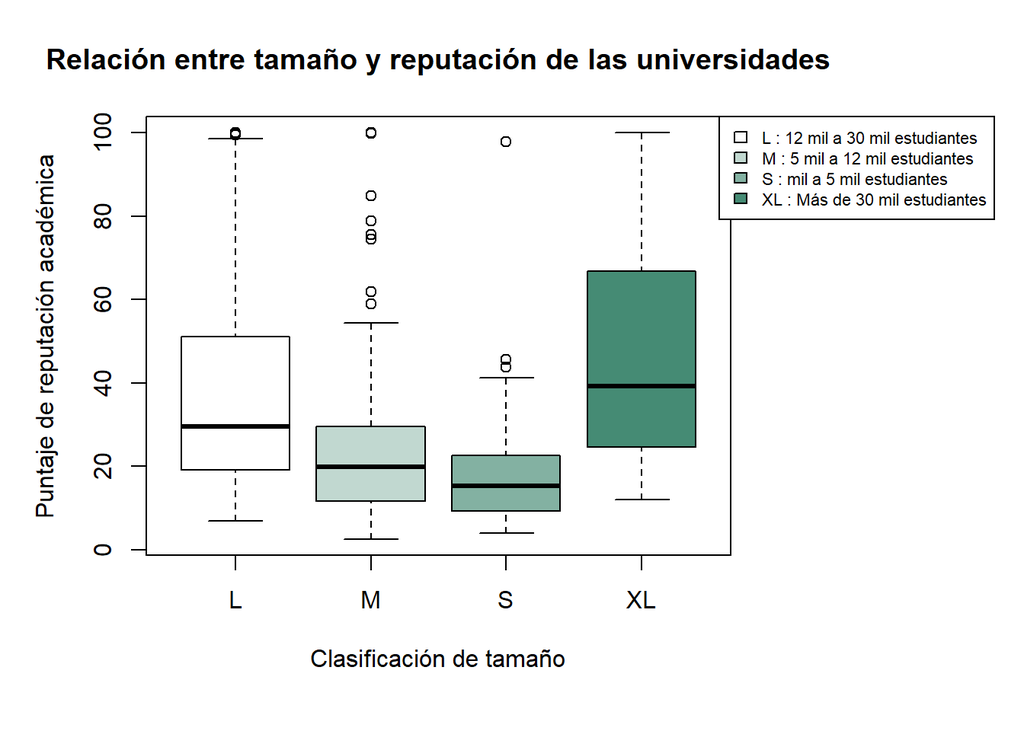

| Clasificación de tamaño | Mediana | Media |
| --- | --- | --- |
| L | 29.50 | 38.39 |
| M | 19.90 | 24.92 |
| S | 15.35 | 19.96 |
| XL | 39.35 | 47.40 |

- De la gráfica inferimos que existe una relación directamente proporcional entre la cantidad de alumnos y el puntaje de reputación académica que tiene una universidad.

Esto podría ser una primera mirada a una de nuestras preguntas de investigación: ¿Se relacionan de manera directa la cantidad de alumnos y el nivel de educación de la universidad?

- Sin embargo, existen casos atípicos en la clasificación M y S, en las que se logra alcanzar e incluso sobrepasar a los puntajes obtenidos de las universidades de mayor clasificación de tamaño.

*“Reputación académica vs Puntaje total”*

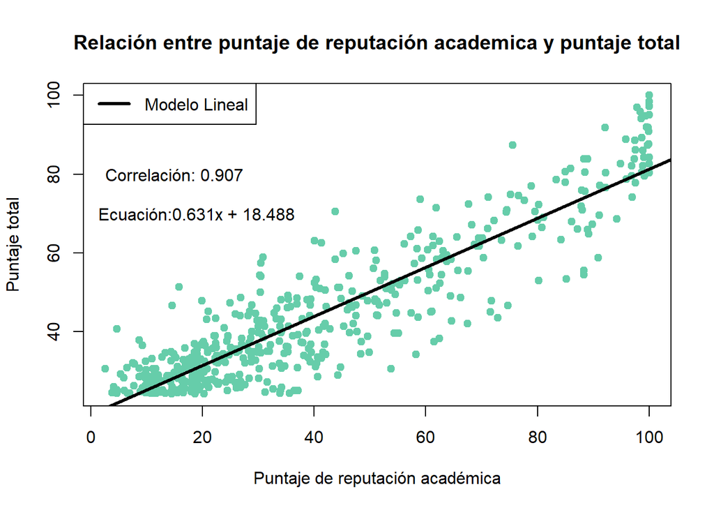

- De la gráfica podemos interpretar, por la distribución de los puntos, existe una tendencia directamente proporcional entre el puntaje de reputación académica y el puntaje total. Esta relación puede ser modelada linealmente, lo cual se puede demostrar con el coeficiente de correlación de Pearson, el cual es aproximadamente 0.9 (cercano a 1).
- La tendencia se ve acentuada en el rango más bajo de puntuación, y también(aunque en menor proporción) en el rango más alto.
- A pesar de lo mencionado anteriormente, existen puntos de la gráfica que no siguen la regla general(mencionada en el primer punto). Por lo que podemos inferir que no siempre un alto puntaje de reputación académica otorga un alto puntaje final, y viceversa.

*“Relación entre Puntaje general y Tiempo de funcionamiento”*

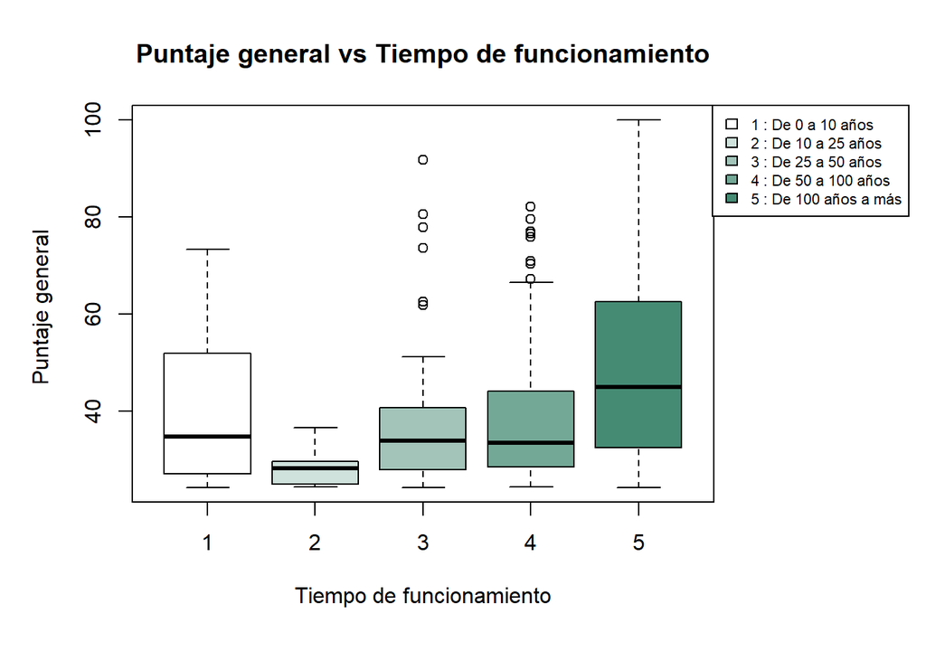

Se sigue una tendencia ascendente desde la escala 2 a 5, exceptuando a los de escala 1. Además en la escala 1, la mediana se encuentra muy alejada del tercer cuartil, por lo que podemos decir que sus datos están dispersos.

Sin embargo, a simple vista, no se puede observar la diferencia de medianas de la escala 3 y 4:

| Tiempo de funcionamiento | Mediana | Coeficiente de variación |
| --- | --- | --- |
| 1 | 34.70 | 0.41 |
| 2 | 28.20 | 0.13 |
| 3 | 33.85 | 0.40 |
| 4 | 33.40 | 0.35 |
| 5 | 44.90 | 0.41 |

La dispersión en casi todas las clasificaciones de tiempo es regular(ni alta ni baja), a excepción de la clasificación 2, que tiene una dispersión baja.

Deducimos entonces, que no necesariamente las universidades relativamente nuevas(de 0 a 10 años), alcancen puntajes bajos, y que las universidades históricas(más de 100 años) no siempre tienen un puntaje alto en el ranking, puesto que en la gráfica se puede ver, que el mínimo de todos es prácticamente igual.

A pesar de esto los máximos conseguidos efectivamente se encuentra en su mayoría en el rango histórico(más de 100 años), aunque cómo en toda tendencia estadística, suelen haber datos atípicos como en la escala 3 y 4.

*“Relación entre Intensidad de investigación y tamaño de las universidades”*

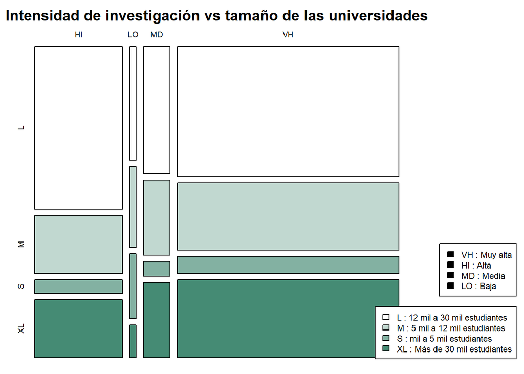

Podríamos pensar que a más cantidad de estudiantes, y por ende más profesionales enseñando por facultad, la intensidad de investigación también sería mayor.

Cabe recalcar que, según la gráfica para las universidades que albergan mas estudiantes, la investigación es un descriptor relevante en las universidades de gran calidad, ya que la casi nula intensidad de investigación baja (LO) se repite en cada una de las categoría de tamaño.

Para finalizar, siendo evidente en todas las universidades de nuestra muestra, se deja claro que la investigación es relevante debido a que intensidad de aparición de la clasificación VH (muy alta) es arrasadora.

## VIII. Figuras de mérito

### Variables Categóricas

#### 1) Distribución de observaciones por continente

**Cantidad de observaciones por cada continente**

```
## Continente
##              África             América                Asia Australia y Oceanía
##                  13                 273                 287                  43
##              Europa
##                 408
```

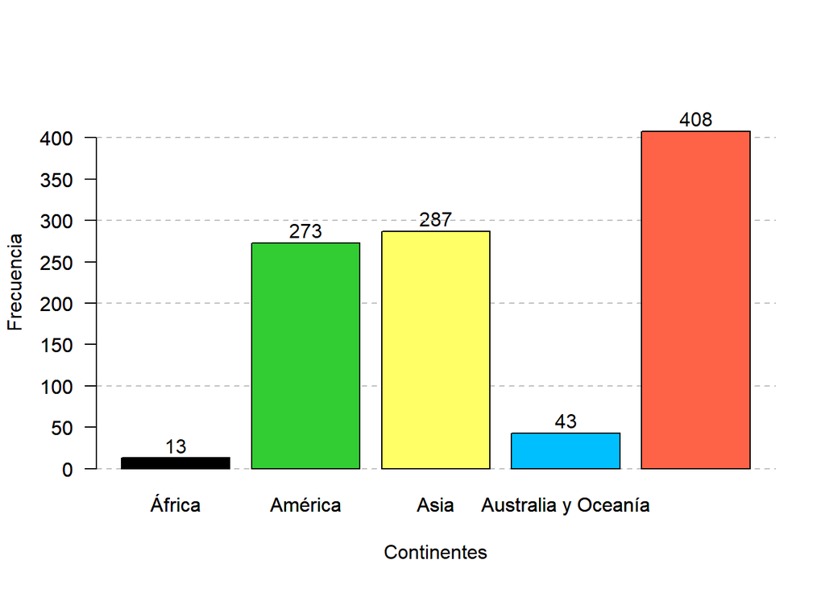

#### 2) Distribución de observaciones por países

**Cantidad de observaciones efectivas para esta variable (de 1024 totales):**

```
## [1] 1024
```

**Cantidad de observaciones con dato faltante en la variable “País”**

```
## [1] 0
```

Las universidades dentro de la muestra pertenecen a diversos países a lo largo del mundo. Para contabilizar la cantidad de universidades existente por país, se generará un dataframe `DPaíses` que contendrá las incidencias de cada país en la muestra:

| País | Cantidad |
| --- | --- |
| Argentina | 13 |
| Australia | 35 |
| Austria | 8 |
| Azerbaijan | 1 |
| Bahrain | 1 |
| Bangladesh | 2 |
| Belarus | 2 |
| Belgium | 8 |
| Brazil | 19 |
| Brunei | 2 |

[output cut: 72 more lines]

Se observa que existen 82 países distintos en la muestra. Para hacer la cantidad por país más relevante (y evitar aglomeraciones en un gráfica), filtraremos a los países con más de 10 incidencias en nuestra data.

| País | Cantidad |
| --- | --- |
| Chile | 11 |
| Colombia | 12 |
| Argentina | 13 |
| Mexico | 13 |
| Netherlands | 13 |
| Poland | 16 |
| Taiwan | 16 |
| Brazil | 19 |
| Malaysia | 20 |
| India | 25 |

[output cut: 12 more lines]

Observamos que luego del filtrado tenemos a 22 países que cuentan con más de 10 incidencias en la muestra. Ahora, ya obteniendo estos datos, elaboraremos una gráfica de barras distribuida en países y continentes.

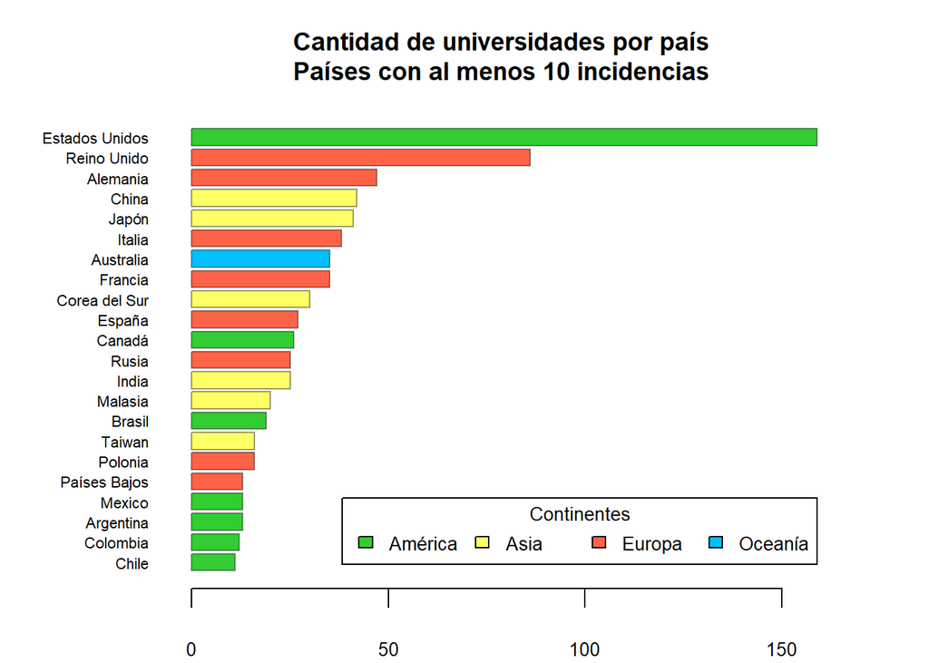

#### 3) Distribución de observaciones por longevidad

**Cantidad de observaciones efectivas para esta variable (de 1024 totales):**

```
## [1] 1001
```

En la data, las universidades también tienen una distribución por longevidad compuesta por números enteros que van de 1 (*Nuevo*) a 5 (*Histórico*). Con las frecuencias con la que aparecen cada tipo, se elaboró un gráfico de barras:

[figure not shown]

Del gráfico, podemos concluir que las universidades dentro del ranking son en su mayoría *históricas* (más de 100 años) y *maduras* (de 50 a 100 años). Esto es razonable, ya que estas universidades alcanzan un **estatus alto** por su arraigo y experiencia.

#### 4) Distribución de observaciones por intensidad de investigación

**Cantidad de observaciones efectivas para esta variable (de 1024 totales):**

```
## [1] 1000
```

La *intensidad de investigación* es el grado de importancia que se le da a la **generación** y **distribución** de contenido *bibliográfico*. En base a este indicador la producción de conocimiento que tiene cada casa de estudio está dividida en 4 niveles.

Para una óptima visualización general de los datos se elaboró una *gráfica de barras* mostrando la *frecuencia* de los 4 niveles que posee esta variable:

```
##
##  HI  LO  MD  VH
## 257  18  78 647
```

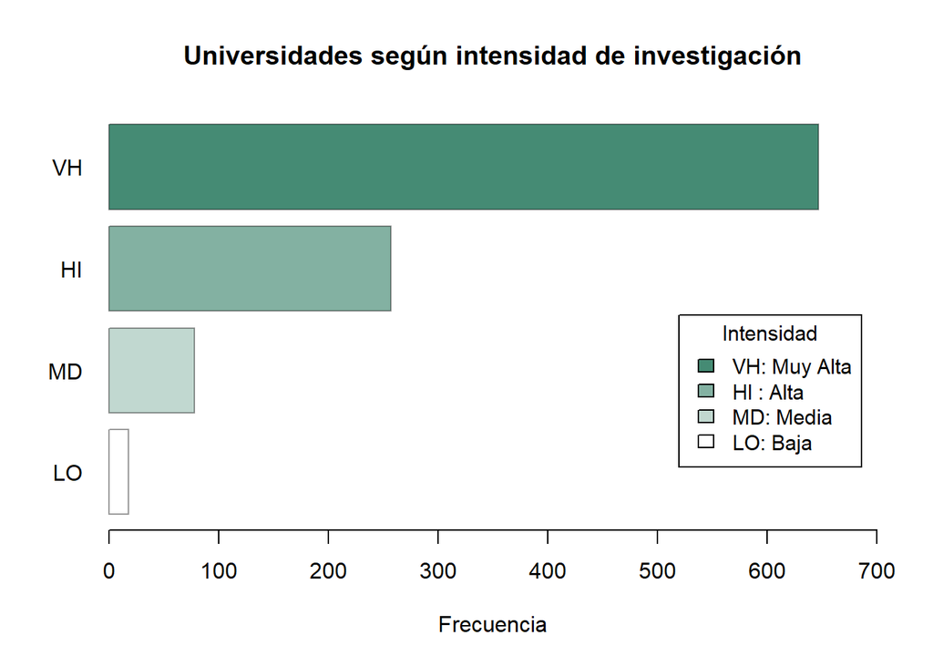

Observamos que más de la mitad de las observaciones son clasificadas como *Intensidad de investigación muy alta*. Esto tiene sentido puesto que siendo universidades del top mundial tienen grandes aportes de conocimiento *científico mundial*.

Para observar mejor la cantidad que representa la categoría *Muy Alta*, podemos elaborar una tabla de probabilidades:

```
##
##    HI    LO    MD    VH
## 0.257 0.018 0.078 0.647
```

Observamos que la categoría *Muy Alta (VH)* abarca más de el 60 % de los datos. Esto confirma nuestra primera observación a partir de la *gráfica de barras*, que daba como predominante a la categoría referida.

#### 5) Distribución de cantidad de estudiantes

**Cantidad de observaciones efectivas para esta variable (de 1024 totales):**

```
## [1] 1024
```

Las universidades también son distribuibles en función a la cantidad de estudiantes que poseen. En este caso, se repartirán en 4 categorías: S, M, L y XL. Lo representamos en un *gráfico de barras*:

```
##
##   L   M   S  XL
## 484 232  59 249
```

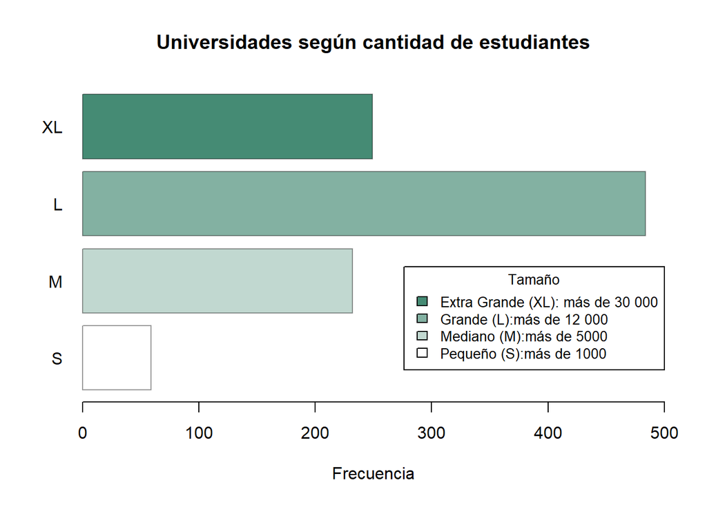

Es evidente que la mayoría de universidades (cerca de 500) están dentro de la categoría *Grande (L)*. Sin embargo, las categorías *Extra Grande (XL)* y *Mediano (M)* son parte significativa también.

Al igual que la variable anterior, podemos ver de mejor manera la distribución con una *tabla de probabilidades*:

```
##
##    L    M    S   XL
## 0.47 0.23 0.06 0.24
```

#### 6) Descripción del estatus de la muestra

**Cantidad de observaciones efectivas para esta variable (de 1024 totales):**

```
## [1] 982
```

El estatus mide el nivel que posee una universidad. Para analizarlo, usaremos también un *gráfico de barras*:

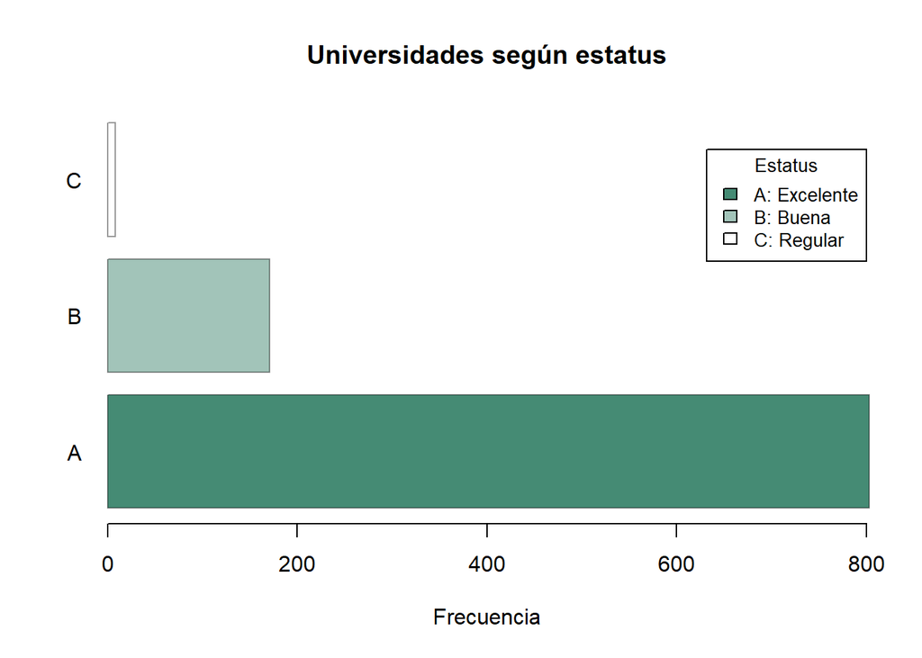

Se observa que la *Categoría A* es abrumadora, con poco más de 800 de las observaciones. Por otro lado, vemos que la presencia de la *Categoría C* es ínfima.

Podemos observar el número que representa *C* y compararla con la cantidad de observaciones efectivas para esta variable, si así lo queremos:

```
##
##   A   B   C
## 803 171   8
```

```
## [1] 982
```

El número tan bajo de incidencias de la *Categoría C* en comparación al total es razonable: *estamos hablando de un ranking de alto nivel, con las mejores universidades del mundo*.

### Variables Numéricas

#### 1) Descripción de la composición extranjera:

**Cantidad de observaciones efectivas para Puntuación por composición de Profesores Extranjeros (de 1024 totales):**

```
## [1] 698
```

**Cantidad de observaciones efectivas para Puntuación por composición de Estudiantes Extranjeros (de 1024 totales):**

```
## [1] 707
```

Analizando las variables relacionadas a la *composición extranjera* de la muestra, `Puntaje de la proporción de profesores internacionales` y `Puntaje de la proporción de estudiantes internacionales`, nos podemos dar una idea de la distribución que se tiene. **Obs:**

Según $QS$ (creadora del ranking), en referencia a las variables:

$Composición$ $Extranjera:$

*Una universidad altamente internacional adquiere y confiere una serie de ventajas. Demuestra la capacidad de atraer profesores y estudiantes de todo el mundo, lo que a su vez sugiere que posee una marca internacional sólida.*

El *análisis* se hará mediante un *boxplot comparativo* y dos *histogramas*.

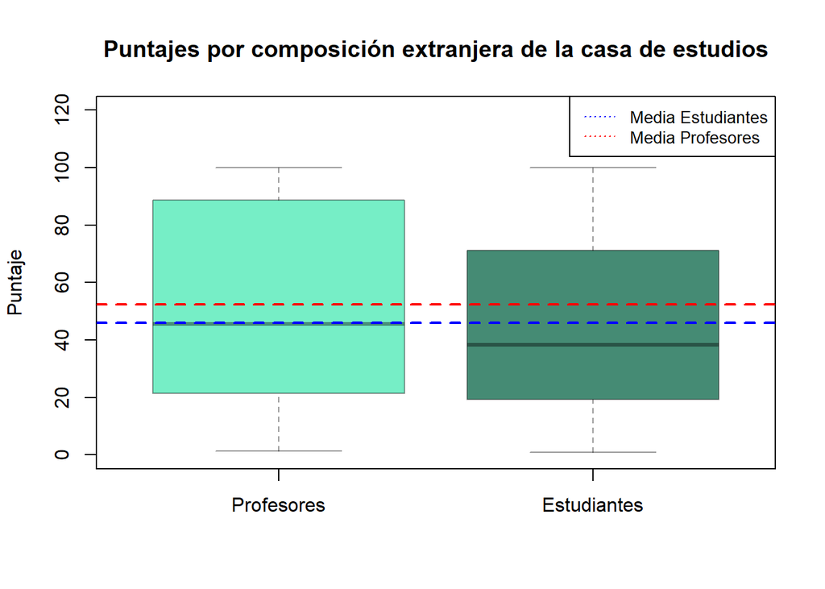

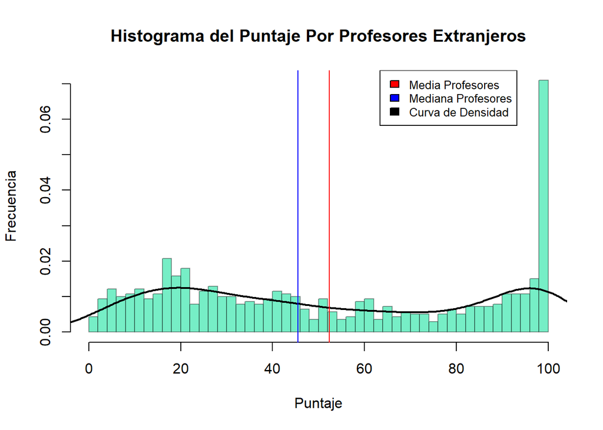

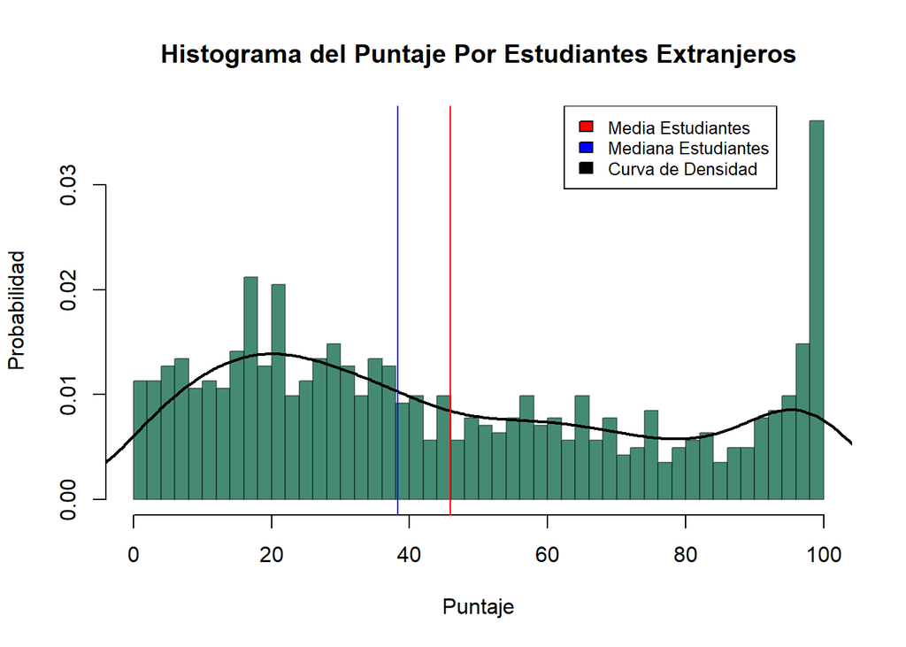

A partir del *boxplot* podemos ver que el *rango intercuartil* de la evaluación de los `Puntos por Profesores Extranjeros` es más amplio que los `Puntos por Estudiantes Extranjeros`, con lo cual podemos concluir que el 50% de las puntuaciones de `Puntos por Profesores Extranjeros` varía más que el 50% de las puntuaciones de los `Puntos por Estudiantes Extranjeros`. Eso sí, ambos tienen variaciones altas, alcanzando un IQR mayor a la mitad del rango total.

Además, en función a la *mediana*, podemos decir también que el 50% de `Puntos por Profesores Extranjeros` está mejor ubicado que el 50% de `Puntos por Estudiantes Extranjeros` . Entonces la muestra en general tiene una mejor evaluación a nivel `Puntos por Profesores Extranjeros` en comparación a `Puntos por Estudiantes Extranjeros`.

Por otro lado, como podemos ver en los *histogramas*, por la configuración de la *mediana-media* tenemos en ambos una distribución con **sesgo a la derecha** . Sin embargo, esta no es muy pronunciada para ninguno, debido a la concentración de datos en la parte derecha de la gráfica que incrementa cuando nos ubicamos cerca a la puntuación máxima. Esto provoca una distorsión en la *curva de nivel*, que en lugar de ser un **pico pronunciado en la izquierda** se convierte en **ondas suaves a lo largo del histograma**.

Es lógico tener para ambas variables una concentración importante al encontrarnos en la zona de puntajes más altos (de 98 a 100 según la distribución del *histograma*). Esto se explica analizando el origen de los datos, que son extraídos de un ranking de las universidades de más alto nivel del mundo (por lo cual es lógico que se alcancen altos puntajes).

Podemos ayudarnos a identificar los *descriptores numéricos* mencionados mediante una **tabla**:

```
##                      Puntuación Profesores Extranjeros
## Media                                            52.40
## Mediana                                          45.55
## Rango Intercuartil                               67.27
##                         Puntuación Estudiantes Extranjeros
## Media                                                 45.9
## Mediana                                               38.3
## Rango Intercuartil                                    52.0
```

#### 2) Descripción del puntaje de Citas por Facultad (Frecuencia de Citado):

**Cantidad de observaciones efectivas para Puntuación por Citas por Facultad (de 1024 totales):**

```
## [1] 695
```

Analizando la variable `Citas por Facultad` nos podemos dar una idea de la distribución del **top** de universidades en referencia a la intensidad con la que las citan (uso del material bibliográfico generado por la casa de estudios).

Según $QS$ (creadora del ranking), en referencia a la variable:

$Citas$ $por$ $Facultad:$

*Para calcularlo, tomamos el número total de citas recibidas por todos los artículos producidos por una institución durante un período de cinco años en proporción al número de miembros de la facultad en esa institución.*

El *análisis* se hará mediante un *boxplot* e *histograma*.

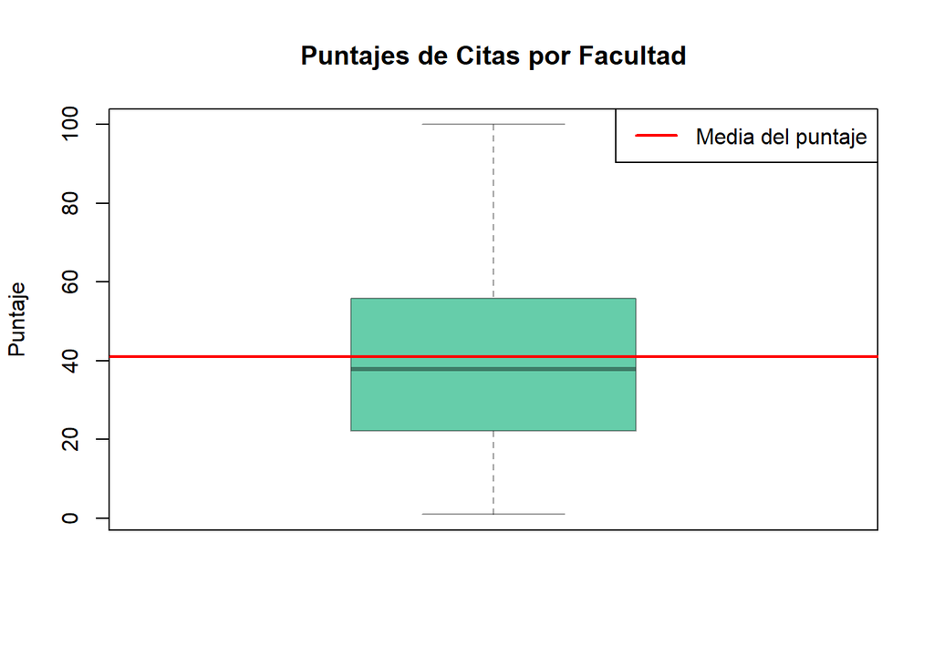

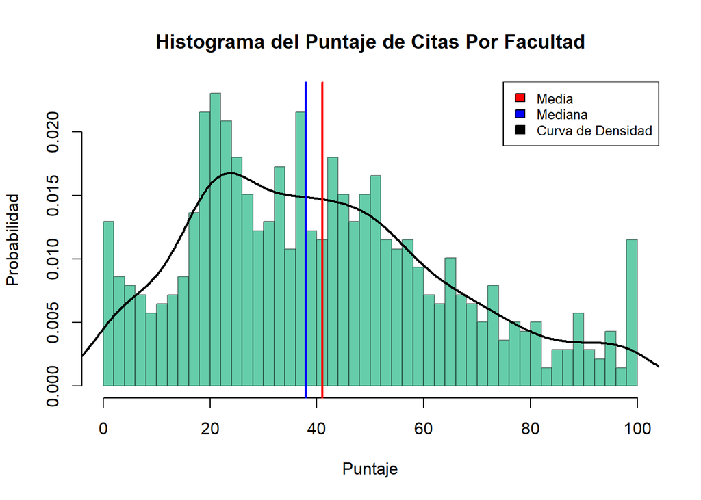

A partir del *boxplot*, nos damos cuenta que la distribución es **sesgada a la derecha**, debido a la ubicación de la *media* respecto de la *mediana*. Además, gracias al *rango intercuartil* nos damos cuenta que la distribución de la mitad de los datos no está muy dispersa.

Analizando el *histograma*, confirmamos estas observaciones. La *curva de densidad* nos muestra una distribución con cola a la derecha o sesgada a la derecha, viéndose afectada mínimamente por la frecuencia que está acumulada en las puntuaciones más altas.

A diferencia de los histogramas anteriores, no se concentra una gran cantidad de datos en los puntajes máximos. Esto nos quiere decir que es más difícil para las universidades del **top** obtener puntajes por sobre 90 en este grupo de datos en comparación a los `Puntajes Por Composición de Profesores Extranjera` y `Puntajes por Composición de Estudiantes Extranjera`.

Al igual que en los datos anteriores, una tabla nos puede ayudar a ubicar mejor los *descriptores numéricos*:

```
##                                  Media   Mediana     Rango Intercuartil
##  Putuación Citas Por Facultad    41.07      37.9                   33.7
```

#### 3) Descripción de los puntajes de Reputación del empleador y Reputación Académica:

**Cantidad de observaciones efectivas para Puntuación de Reputación Laboral (de 1024 totales):**

```
## [1] 635
```

**Cantidad de observaciones efectivas para Puntuación de Reputación Académica (de 1024 totales):**

```
## [1] 592
```

Analizando las variables `Reputación del empleador` y `Reputación Académica` observaremos la distribución de las universidades respecto a los puntajes obtenidos como apreciación de los empleadores (contratantes de los egresados).

Según $QS$ (creadora del ranking), en referencia a las variables:

$Reputación$ $Laboral:$ *Nuestra métrica de Reputación del empleador se basa en más de 75.000 respuestas a nuestra Encuesta de empleadores de QS y solicita a los empleadores que identifiquen las instituciones de las que obtienen los graduados más competentes, innovadores y eficaces. La Encuesta de empleadores de QS también es la más grande del mundo en su tipo.*

Compararemos a la variable anterior con la `Reputación Académica` que posee la muestra.

$Reputación$ $Académica:$ *Basado en nuestra Encuesta Académica , recopila las opiniones de expertos de más de 130.000 personas en el espacio de la educación superior con respecto a la calidad de la enseñanza y la investigación en las universidades del mundo. Al hacerlo, ha crecido hasta convertirse en la encuesta de opinión académica más grande del mundo y, en términos de tamaño y alcance, es un medio incomparable para medir el sentimiento en la comunidad académica.*

El *análisis* se hará efectivo a través de un *boxplot comparativo* e *histogramas*.

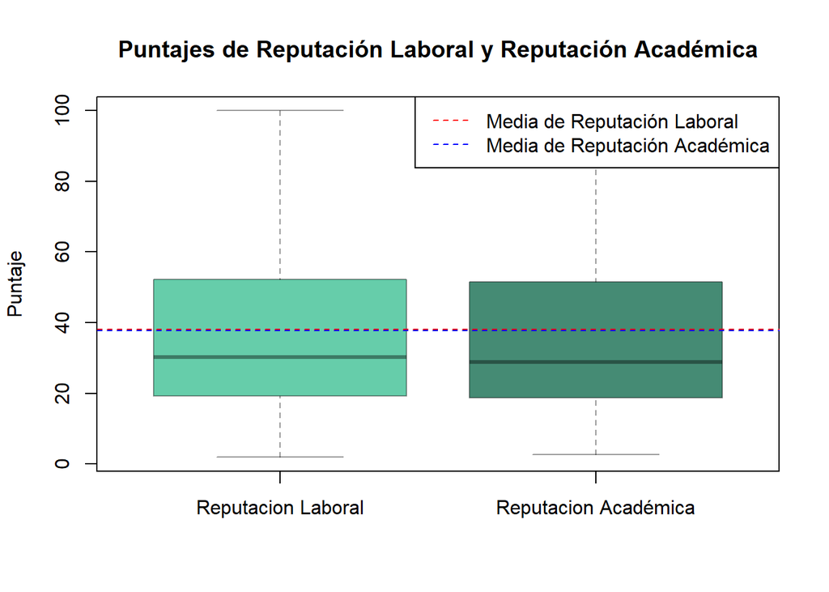

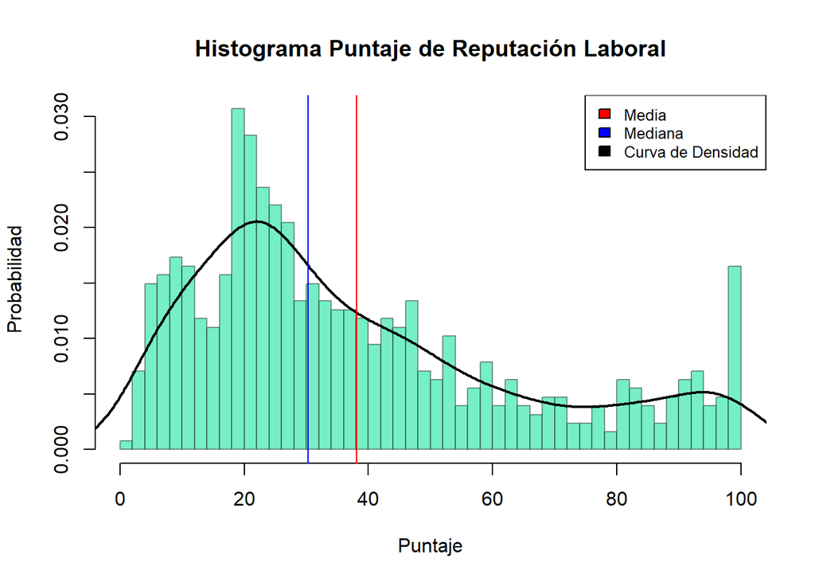

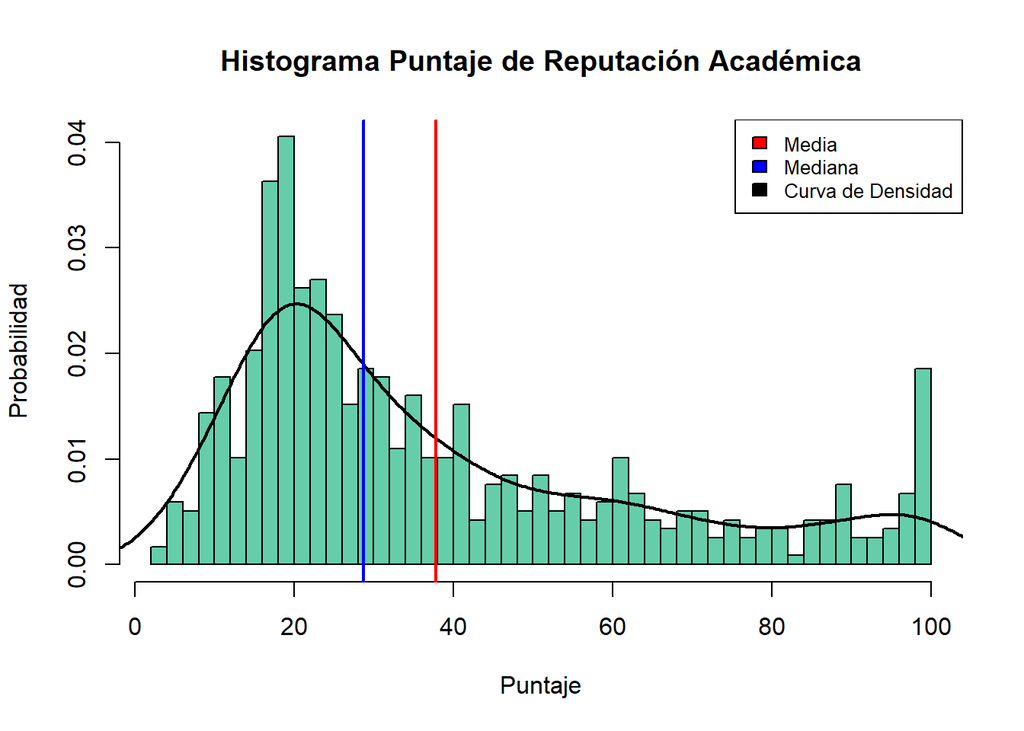

Del *boxplot comparativo* observamos *a priori* cajas y bigotes idénticos para ambas variables, lo cual puede sugerir una fuerte relación entre ambas. Por la ubicación de la *media* y *mediana*, podemos describir los conjuntos como sesgados a la derecha. Por otro lado, el *rango intercuartil* no es muy amplio, lo cual indica que no existe gran dispersión entre la mitad de datos ubicados alrededor de la *mediana*.

Viendo el *histograma*, es mucho más notoria la cola hacia la derecha de la distribución. Viendo la *curva de densidad*, notamos que existe un pico bastante pronunciado hacia la izquierda, agrupando los datos hacia este lado. Esto evidencia la dificultad del grupo de universidades **top** de alcanzar valores altos de puntuación en la evaluación presentada por el *empleador*.

Facilitamos la lectura de los principales *descriptores numéricos* presentados a través de una tabla:

```
##                       Puntuación de Reputación Laboral
## Media                                            38.11
## Mediana                                          30.30
## Rango Intercuartil                               33.00
##                      Puntuación de Reputación Académica
## Media                                             37.79
## Mediana                                           28.75
## Rango Intercuartil                                32.80
```

A través de esta *tabla*, confirmamos la gran similitud de los *descriptores numéricos* para ambos.

#### 4) Descripción del puntaje de la Proporción Profesores - Estudiantes:

**Cantidad de observaciones efectivas para Puntuación de Proporción Profesores - Estudiantes (de 1024 totales):**

```
## [1] 719
```

Analizando la variable `Proporción Profesores - Estudiantes` tendremos un acercamiento a como está evaluado este conjunto respecto a la cantidad de catedráticos disponibles para el conjunto estudiantil.

Según $QS$ (creadora del ranking), en referencia a la variable:

$Proporción$ $Profesores$ $-$ $Estudiantes:$

*Los estudiantes suelen citar la calidad de la enseñanza como la métrica de mayor importancia para ellos cuando comparan instituciones que utilizan una clasificación. Evalúa hasta qué punto las instituciones pueden brindar a los estudiantes un acceso significativo a profesores y tutores, y reconoce que un alto número de miembros de la facultad por estudiante reducirá la carga docente de cada académico individual.*

El *análisis* se hará efectivo a través de un *boxplot* e *histograma*.

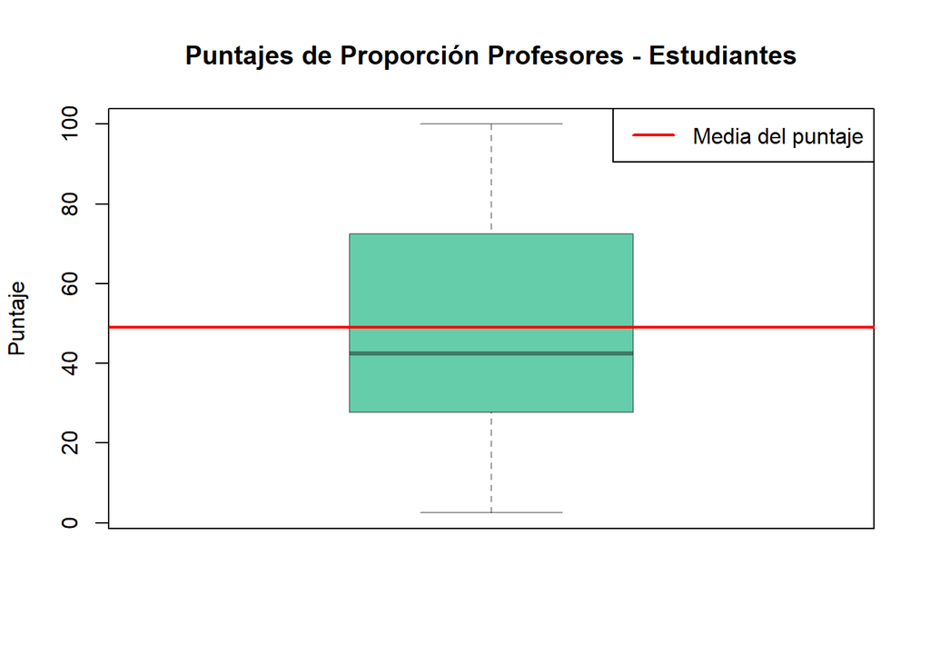

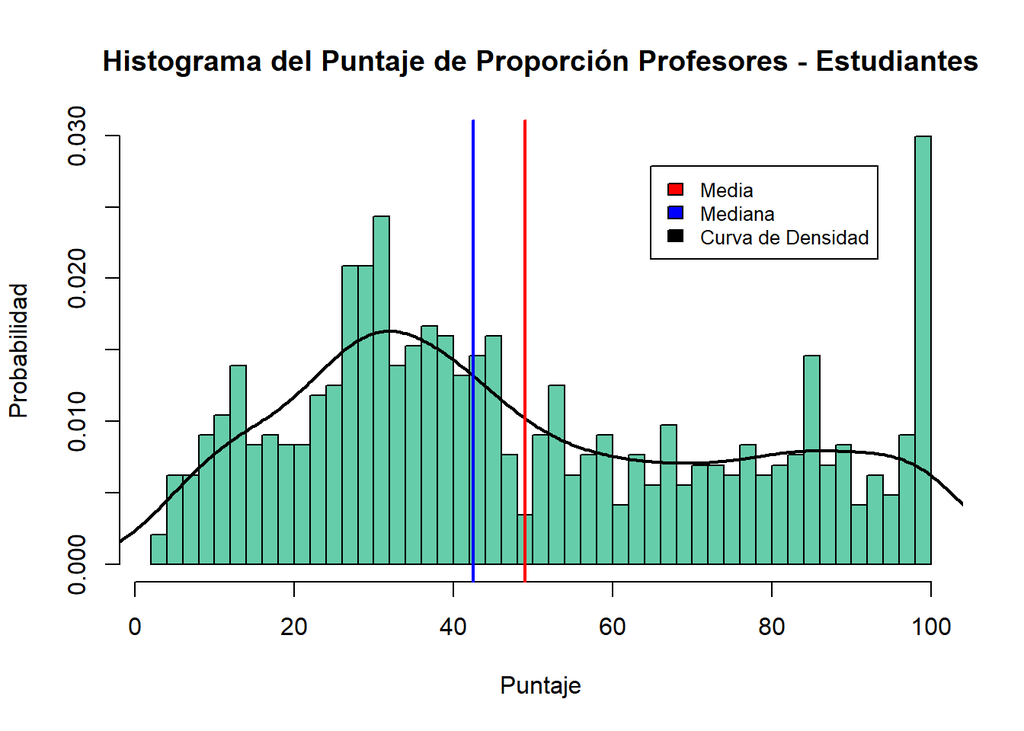

En el *boxplot* seguimos viendo la tendencia de una *media* superior a la *mediana*, indicándonos un sesgo a la derecha en el conjunto de datos. Además, la caja abarca cerca de la mitad del rango, por lo que la mitad de los datos está medianamente disperso.

En nuestro *histograma* confirmamos el sesgo a la derecha, obteniendo una acentuación de la *curva de nivel* hacia el lado izquierdo. La elevación se ve reducida debido a la acumulación de valores en el lado derecho de la *curva* (fenómeno observado y explicado en gráficas anteriores).

Al igual que antes, una tabla de *descriptores numéricos* es útil para obtener los valores exactos mencionados:

```
##                       Puntuación de Proporción Estudiantes - Profesores
## Media                                                             49.02
## Mediana                                                           42.50
## Rango Intercuartil                                                44.70
```

### IX. Comparación de Variables Numéricas:

Para comparar las variables numéricas obtenidas, usaremos en primer lugar un *boxplot comparativo*:

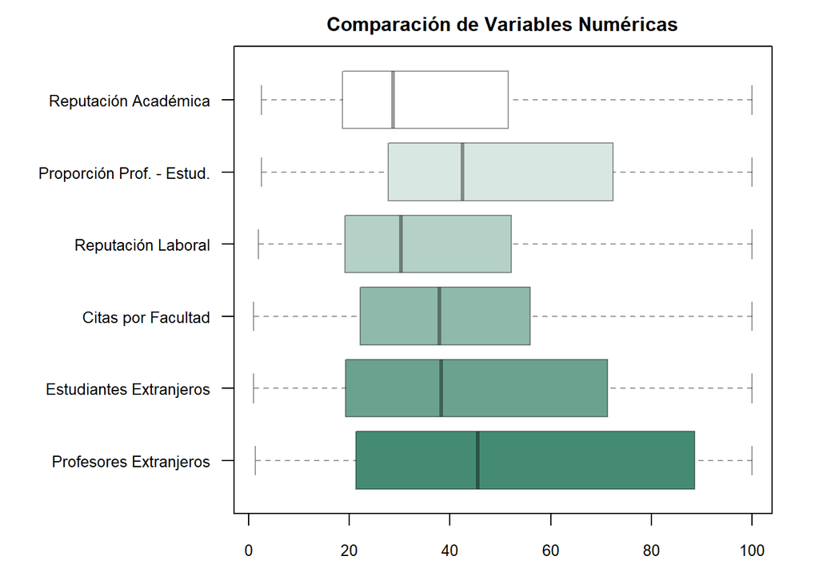

Analizaremos los datos que se encuentren sobre el *3er cuartil* (el 25 % superior de los datos). En los puntajes de `Profesores Extranjeros` se ve una clara concentración de este grupo entre los valores de 90 a 100 aproximadamente. De forma un poco menos alta (entre los valores de 70 a 100) los valores de `Estudiantes Extranjeros` y `Proporción Profesores - Estudiantes` presentan una tendencia similar. Para estas variables, esto indicaría una tendencia de puntajes altos, saliendo la muestra en general mejor evaluada en estos aspectos.

Además , gracias al *rango intercuartil* o *IQR* (indicado por el alto de la caja), nos damos cuenta que la variable más dispersa en el 50 % de sus datos es `Profesores Extranjeros` con un rango intercuartílico (*a priori*) de más de 60. Por otro lado, las variables `Citas por Facultad`, `Reputación Académica` y `Reputación Laboral` presentan los rango intercuartílicos más compactos, es decir, con la mitad de sus datos menos dispersos.

Ahora analizaremos los *histogramas* en conjunto:

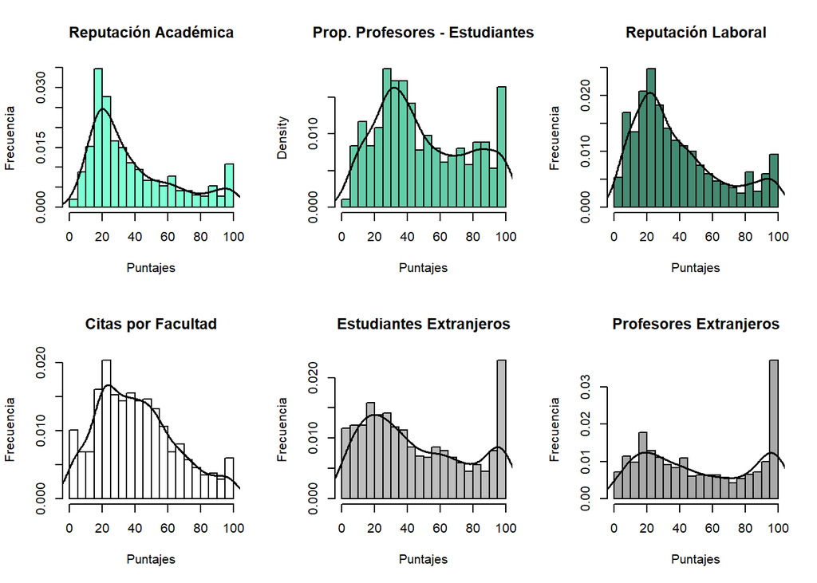

Viendo y comparando los histogramas, vemos que nuestras predicciones anteriores son correctas: las variables `Profesores Extranjeros`, `Estudiantes Extranjeros` y `Proporción Profesores - Estudiantes` presentan aglomeraciones al lado derecho de la gráfica obteniendo varios datos con puntuaciones altas.

Observando las otras tres gráficas, nos damos cuenta que `Citas por Facultad`, `Reputación Académica` y `Reputación Laboral` tienen una configuración fuertemente sesgada a la derecha. De esta configuración podemos decir que la muestra en general toma valores más bajos para estas tres categorías (concentrándose la mayoría de valores tomados a la izquierda). Entonces, establecemos que a la muestra en general le resulta más difícil alcanzar altos puntajes en `Citas por Facultad` (cómo se desempeñan en la producción de conocimiento), `Reputación Académica` (cómo son vistos, reconocidos y evaluados por sus pares) y `Reputación Laboral` (cómo son vistos, reconocidos y evaluados por las empresas/compañías que contratan a sus egresados).

Para una mejor apreciación de los *descriptores numéricos* en los cuales nos apoyamos para el análisis, presentamos un *cuadro*:

```
##                                    Media   Mediana   Rango Intercuartil
## Reputación Académica               37.79     28.75                32.80
## Proporción Profesores Estudiantes  49.02     42.50                44.70
## Reputación Laboral                 38.11     30.30                33.00
## Citas por Facultad                 41.07     37.90                33.70
## Estudiantes Extranjeros            45.90     38.30                52.00
## Profesores Extranjeros             52.40     45.55                67.27
```

## X. Relaciones entre variables

*“Relación entre reputación del empleador y puntaje total”*

Hecho esto, ahora sí podemos seguir trabajando.

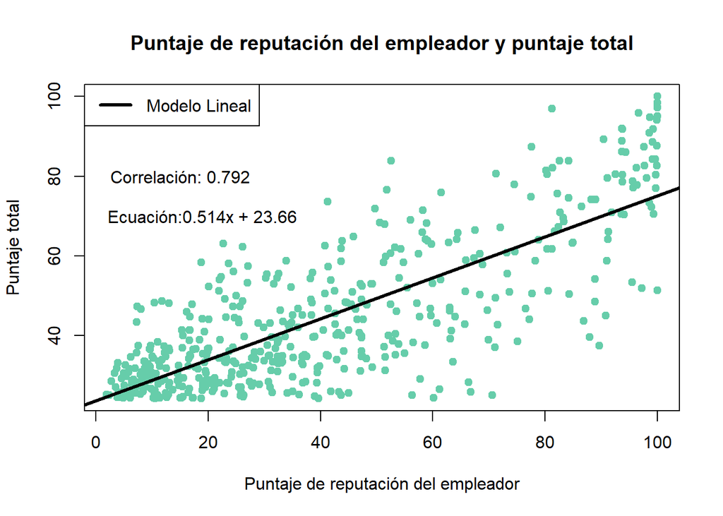

- La gráfica presenta un comportamiento y análisis similar al anterior, pues también existe una tendencia directamente proporcional, por la distribución de los puntos, entre el puntaje de reputación del empleador y el puntaje total. Sin embargo, al ser modelada linealmente, observamos que su coeficiente de correlación de Pearson es aproximadamente 0.8. Aunque sea cercano a 1, es menor a la correlación del gráfico anterior, es así como observamos una mayor dispersión entre la relación de los puntos de esta gráfica.
- La tendencia se ve acentuada en el rango más bajo de puntuación, y también, aunque en menor proporción, en el rango más alto.
- De igual manera que en el anterior gráfico, existen puntos de la gráfica que no siguen una tendencia directamente proporcional. Por lo que inferimos que no siempre un alto puntaje de reputación del empleador otorga un alto puntaje total, y viceversa.

*“Relación entre Puntaje general y Clasificación del tamaño”*

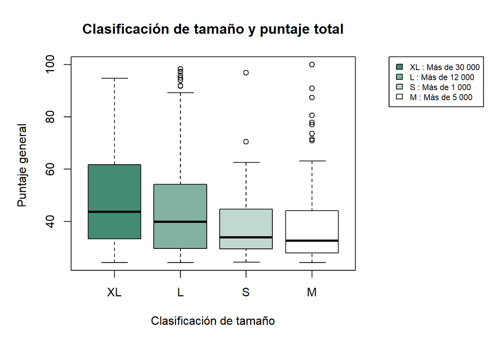

En la gráfica podemos observar que las medianas se encuentran más cercanas del primer cuartil, por lo que podemos decir que sus datos presentan una notoria dispersión. Además, a simple vista, no se puede observar la diferencia de medianas de la escala “S” y “M”.

Hecho esto, ahora sí podemos seguir trabajando.

**- Medianas:**

```
##    Mediana Coeficiente de Variación
## XL    43.7                     0.39
## L     39.8                     0.42
## S     33.9                     0.41
## M     32.6                     0.43
```

Con los datos anteriores podemos observar que la mediana de S es apenas superior a la mediana de M.

La dispersión de las clasificaciones de tamaño es regularmente alta pues observamos marcadas distancias entre sus cuartiles.

Deducimos entonces, que no necesariamente las universidades con una gran capacidad de personal estudiantil alcanzan puntajes altos, y que las universidades con una menor capacidad estudiantil no siempre tienen puntajes bajos en el ranking, puesto que en la gráfica se puede ver que el mínimo de todos es prácticamente igual.

*“Relación entre Puntaje general y Clasificación de estatus”*

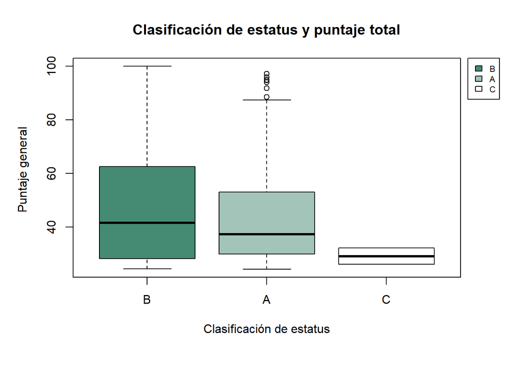

En la gráfica podemos observar que las medianas de las escalas de A y B se encuentra más cercanas del primer cuartil, por lo que podemos decir que sus datos presentan una notoria dispersión. Además, a simple vista, se puede observar que las universidades con un estatus C son mínimas, tanto así que apenas el boxplot de la escala C es visible. Esto se debe a que la cantidad de observaciones es mínima, incluso llega a ser de solo 8 observaciones como podemos ver a continuación:

```
##
##   A   B   C
## 803 171   8
```

Hecho esto, ahora sí podemos seguir trabajando.

```
##   Frecuencia Mediana del puntaje general
## A        803                       37.20
## B        171                       41.50
## C          8                       29.05
##   Coeficiente de Variación del puntaje general
## A                                         0.40
## B                                         0.49
## C                                         0.15
```

Deducimos entonces, que no necesariamente las universidades con un estatus de clasificación A son las que ocupan los valores más altos de puntaje, y que las universidades con una clasificación de estatus B no siempre tienen puntajes bajos en el ranking, puesto que en la gráfica se puede ver que el mínimo de A y B es prácticamente igual.

*“Relación entre Puntaje general y Clasificación de intensidad de investigación”*

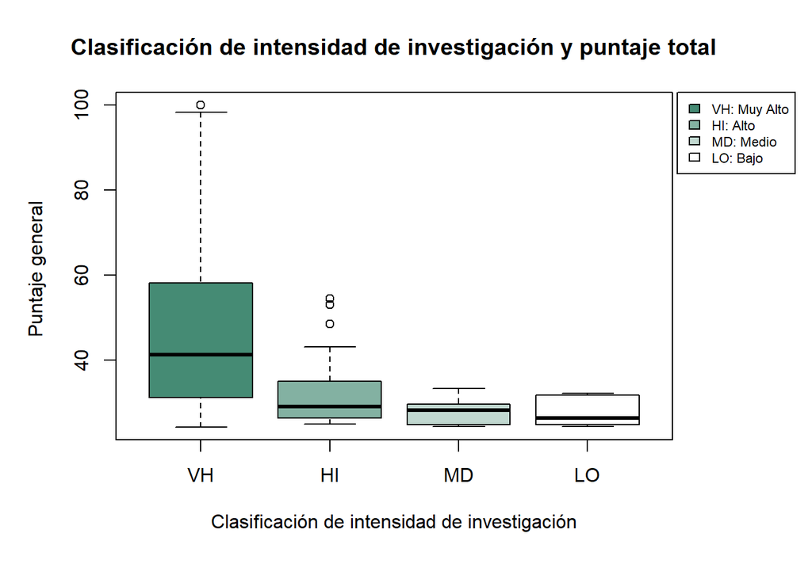

Es así como analizaremos cada escala para tener una mayor precisión de los datos obtenidos.

Hecho esto, ahora sí podemos seguir trabajando.

```
##    Mediana Coeficiente de Variación
## VH    41.2                     0.41
## HI    29.0                     0.23
## MD    28.2                     0.11
## LO    26.3                     0.14
```

Con los datos anteriores podemos observar que la mediana de HI es superior por poco a la mediana de MD.

La dispersión de las clasificaciones de estatus es relativamente baja pues no se observan unas distancias marcadas entre sus cuartiles. Aunque vemos que la escala VH presenta una gran dispersión de sus valores y que la escala HI tiene unos cuantos datos atípicos, aunque no se puede comparar con la cantidad de datos de la escala VH

Deducimos entonces, que la clasificación de intensidad de investigación influye directamente en el puntaje general obtenido por las universidades debido a que las universidades con una clasificación VH (Muy Alto) son las que ocupan los valores más altos de puntaje. Asimismo, las universidades con un clasificación diferente a VH tienen puntajes bajos en el ranking, tal como se observa en el gráfico.

*“Relación entre Puntaje general y Puntaje de Reputación académica por continentes”*

```
##                               América  Asia Australia y Oceanía Europa África
## Media de Reputación académica   42.69 34.71               42.32  36.10  29.85
## Media de Puntaje general        47.96 42.52               45.00  43.27  31.95
```

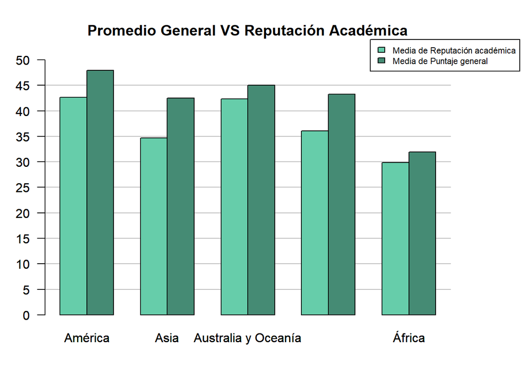

*“Promedio de puntajes por composición extranjera”*

```
##                                                    América  Asia
## Media de proporción de estudiantes internacionales   40.94 30.89
## Media de proporción de profesores internacionales    43.15 44.41
##                                                    Australia y Oceanía Europa
## Media de proporción de estudiantes internacionales               80.14   51.4
## Media de proporción de profesores internacionales                91.30   56.8
##                                                    África
## Media de proporción de estudiantes internacionales  25.00
## Media de proporción de profesores internacionales   53.72
```

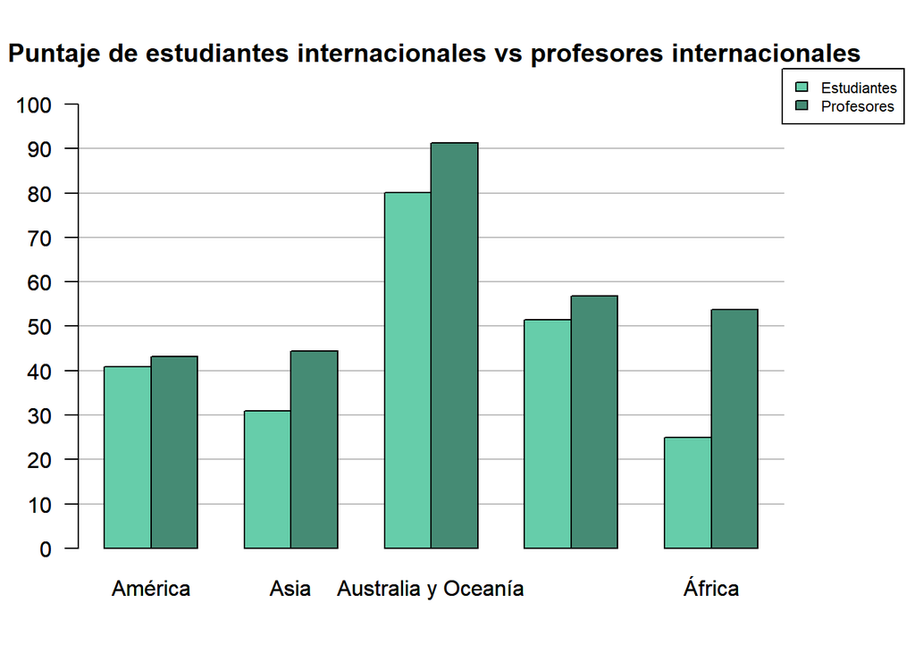

## XI VARIABLE ALEATORIAS

### Binomial

#### Puntaje general

Cantidad total de datos disponibles

```r
DatosDisponibles <- sum(!is.na(DF$`Puntaje general`))
DatosDisponibles
```

```
## [1] 500
```

Cantidad de universidades estudiadas

```r
nrow(DF)
```

```
## [1] 1024
```

Nuestro muestreo es del tipo discrecional, es decir muy similar a un muestreo por conveniencia. Como estamos hablando de un *Ranking de universidades top* podríamos esperar que la mayoría pase un puntaje general, que es el que define su posición en el ranking, de 50 puntos.

**Éxito** –> Puntaje mayor o igual a 50

**Fracaso** –> Puntaje menor a 50

A continuación mostramos la cantidad de universidades que logran igualar o pasar los 50 puntos y las que no lo logran.

| Continente | Puntaje igual o mayor a 50 | Puntaje menor a 50 |
| --- | --- | --- |
| África | 0 | 4 |
| América | 48 | 79 |
| Asia | 31 | 91 |
| Australia y Oceanía | 10 | 24 |
| Europa | 62 | 151 |

## En general

Primero veremos la probabilidad de que las universidades, sin importar el continente al que pertenezcan, pasen o igualen los 50 puntos.

**Probabilidad de éxito**

**Éxito** –> Puntaje mayor o igual a 50

```r
nrow(M)/DatosDisponibles
```

```
## [1] 0.302
```

**Probabilidad de fracaso**

**Fracaso** –> Puntaje menor a 50

```r
nrow(N)/DatosDisponibles
```

```
## [1] 0.698
```

**Éxito** –> Puntaje mayor o igual a 50

**Fracaso** –> Puntaje menor a 50

La probabilidad de que el 50% de las universidades estudiadas tengan un **puntaje igual o mayor a 50** es:

```r
dbinom(512,1024,0.302)
```

```
## [1] 2.943952e-40
```

La probabilidad de que al menos el 50% de las universidades estudiadas tengan un **puntaje menor a 50**es:

```r
sum(dbinom(c(512:1024),1024,0.698))
```

```
## [1] 1
```

### Probabilidad condicional

#### Posición en el ranking por continente

**TABLA DE FRECUENCIA**

[output not shown]

**TABLA DE PROBABILIDAD**

[output not shown]

# Creando modelos de variables aleatorias:

## 1) Distribución binomial:

Tenemos la variable `Tiempo de Funcionamiento`, la cual explica la longevidad de las universidades en un rango del 1 al 5. Para saber la probabilidad que tiene cada categoría en esta variable, crearemos una *tabla de probabilidades*:

```
##
##    1    2    3    4    5
## 0.02 0.04 0.15 0.31 0.49
```

Como estamos hablando de **probabilidades**, estas deberían sumar **1** (o un número bastante aproximado, debido al redondeo):

```
## [1] 1.01
```

Una vez obtenidas las probabilidades de cada *valor posible* de la **variable**, buscaremos obtener modelos binomiales a partir de estos:

### Primer modelo: *Individual*

#### Usando una categoría abundante:

Dentro de nuestra muestra mundial, tenemos una gran mayoría de universidades de gran longevidad (entre Histórico y Maduro). Sabemos que la probabilidad es de 0.49 para la categoría **5: Histórico**, siendo esta la más alta entre las categorías de gran longevidad. Si escogemos aleatoriamente 500 universidades de la muestra, que viene a ser aproximadamente el número de apariciones totales de esta categoría en el ranking de Quacquarelly Symonds. ¿Cuál es la probabilidad de que la mitad de la selección sea de categoría **5: Histórico**?

**éxito**: Que sea de categoría **5**

**fracaso**: Que *no* sea de categoría **5**

```
## [1] 0.032
```

Entonces, obtenemos una probabilidad de 0.032 de obtener 250 universidades de categoría **5** al escoger 500 al azar. Conseguimos un número significativo debido a la medianamente alta probabilidad con la que aparece esta variable. Si la probabilidad disminuyera, la posibilidad de encontrar grupos numerosos como el anterior podría ser tan escasa que se aproximaría a 0. Buscaremos respaldar esta afirmación a través del próximo experimento.

#### Usando una categoría escasa:

Antes, postulamos que una categoría de baja aparición daría probabilidades bajísimas e incluso nulas de aparecer si se busca en grupos grandes. Entre nuestras categoría de más bajas apariciones tenemos a Nuevo y Joven, con menos del 0.05 de probabilidad de aparición para ambas. Sabemos que la probabilidad es de 0.02 para la categoría **1: Nuevo** (que es la más baja entre ambas). Si escogemos aleatoriamente 500 universidades de la muestra (para obtener las mismas condiciones del caso anterior) ¿Cuál es la probabilidad de que la mitad sea de categoría **1: Nuevo**?

**éxito**: Que sea de categoría **1**

**fracaso**: Que *no* sea de categoría **1**

```
## [1] 0
```

Entonces, obtenemos una probabilidad de 0 de obtener 250 universidades de categoría **1** al escoger 500 al azar. Esto es lógico, ya que su poquísima incidencia la hace improbable de aparecer en conjuntos tan grandes. Con esto confirmamos el análisis inferencial que hicimos en base al experimento anterior.